title: “Human Activity Recognition” author: “Haftom” date: “October 19, 2018” output: html_document —

## Background

Using devices such as Jawbone Up, Nike FuelBand, and Fitbit it is now possible to collect a large amount of data about personal activity relatively inexpensively. These type of devices are part of the quantified self movement - a group of enthusiasts who take measurements about themselves regularly to improve their health, to find patterns in their behavior, or because they are tech geeks. One thing that people regularly do is quantify how much of a particular activity they do, but they rarely quantify how well they do it. In this project, your goal will be to use data from accelerometers on the belt, forearm, arm, and dumbell of 6 participants. They were asked to perform barbell lifts correctly and incorrectly in 5 different ways. More information is available from the website here: http://groupware.les.inf.puc-rio.br/har (see the section on the Weight Lifting Exercise Dataset).

#### Data

The training data for this project are available here: https://d396qusza40orc.cloudfront.net/predmachlearn/pml-training.csv The test data are available here: https://d396qusza40orc.cloudfront.net/predmachlearn/pml-testing.csv The data for this project come from this source: http://groupware.les.inf.puc-rio.br/har. If you use the document you create for this class for any purpose please cite them as they have been very generous in allowing their data to be used for this kind of assignment.

#### Getting ready

```r
rm(list=ls())
require(tree)
```

```r
require(ggplot2)
require(caTools)
require(caret)
require(dplyr)
library(randomForest)
library(e1071)
library(gbm)
set.seed(12345)
```

#### Getting Data

```r
# download the datasets
train<- read.csv("http://d396qusza40orc.cloudfront.net/predmachlearn/pml-training.csv")
sample<-sample.split(train$classe,SplitRatio = 0.70)
train_data<-subset(train,sample==TRUE)
test_data<-subset(train,sample==FALSE)
```

#### Handling NA’s

So much NA’s would be removed using The Near Zero variance (NZV).

```r
#Checking for NA
table(is.na(train))
```

```
##
##   FALSE    TRUE
## 1852048 1287472
```

```r
# remove variables with Nearly Zero Variance
remove1 <- nearZeroVar(train_data)
Train_c <- train_data[, -remove1]
Test_c  <- test_data[, -remove1]
dim(Train_c)
```

```
## [1] 13735   105
```

Removing columns that contains so much NA’s

```r
remove2<- sapply(Train_c, function(x) mean(is.na(x))) > 0.95
Train_final <- Train_c[, remove2==FALSE]
Test_final  <- Test_c[,remove2==FALSE]

#Removing columns that are not required for modleing
Train_final <- Train_final[, -(1:5)]
Test_final <- Test_final[, -(1:5)]

dim(Train_final)
```

```
## [1] 13735    54
```

```r
dim(Test_final)
```

```
## [1] 5887   54
```

#### Model One (Tree)

```r
#Training
tree_model<-tree(classe~.,data=Train_final)
summary(tree_model)
```

```
##
## Classification tree:
## tree(formula = classe ~ ., data = Train_final)
## Variables actually used in tree construction:
##  [1] "roll_belt"         "pitch_forearm"     "roll_forearm"
##  [4] "magnet_dumbbell_x" "num_window"        "magnet_dumbbell_y"
##  [7] "magnet_dumbbell_z" "pitch_belt"        "yaw_belt"
## [10] "roll_dumbbell"     "accel_forearm_x"
## Number of terminal nodes:  19
## Residual mean deviance:  1.524 = 20900 / 13720
## Misclassification error rate: 0.3094 = 4250 / 13735
```

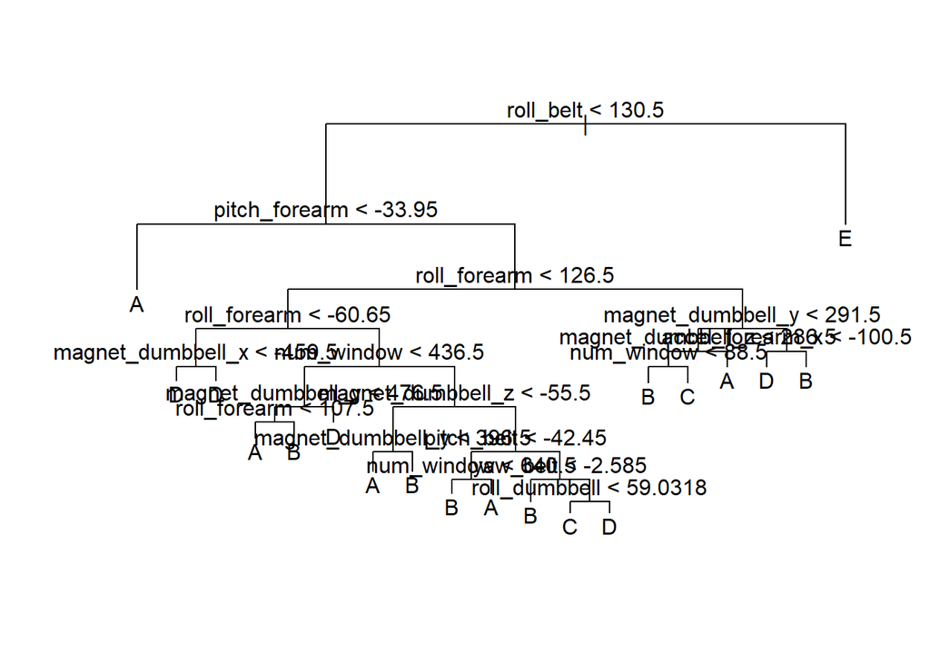

```r
plot(tree_model)
text(tree_model,pretty=0)
```

```r
#Testing
predict_Tree <- predict(tree_model, newdata=Test_final, type="class")
conf_Tree <- confusionMatrix(predict_Tree, Test_final$classe)
conf_Tree
```

```
## Confusion Matrix and Statistics
##
##           Reference
## Prediction    A    B    C    D    E
##          A 1433  109    6    8   41
##          B   84  630   86   68  137
##          C   13   46  788  224   64
##          D  132  247  110  637  220
##          E   12  107   37   28  620
##
## Overall Statistics
##
##                Accuracy : 0.6978
##                  95% CI : (0.6859, 0.7095)
##     No Information Rate : 0.2844
##     P-Value [Acc > NIR] : < 2.2e-16
##
##                   Kappa : 0.6192
##  Mcnemar's Test P-Value : < 2.2e-16
##
## Statistics by Class:
##
##                      Class: A Class: B Class: C Class: D Class: E
## Sensitivity            0.8560   0.5531   0.7673   0.6601   0.5730
## Specificity            0.9611   0.9210   0.9286   0.8560   0.9617
## Pos Pred Value         0.8973   0.6269   0.6943   0.4733   0.7711
## Neg Pred Value         0.9438   0.8957   0.9497   0.9278   0.9091
## Prevalence             0.2844   0.1935   0.1745   0.1639   0.1838
## Detection Rate         0.2434   0.1070   0.1339   0.1082   0.1053
## Detection Prevalence   0.2713   0.1707   0.1928   0.2286   0.1366
## Balanced Accuracy      0.9086   0.7371   0.8479   0.7580   0.7674
```

#### Model two (Random Forest)

```r
#Modeling
forest_model<-randomForest(classe~.,Train_final,mtyr=54,importance=TRUE)
forest_model
```

```
##
## Call:
##  randomForest(formula = classe ~ ., data = Train_final, mtyr = 54,      importance = TRUE)
##                Type of random forest: classification
##                      Number of trees: 500
## No. of variables tried at each split: 7
##
##         OOB estimate of  error rate: 0.33%
## Confusion matrix:
##      A    B    C    D    E  class.error
## A 3905    0    0    0    1 0.0002560164
## B    4 2652    2    0    0 0.0022573363
## C    0   14 2379    2    0 0.0066805846
## D    0    0   16 2234    1 0.0075521990
## E    0    0    0    6 2519 0.0023762376
```

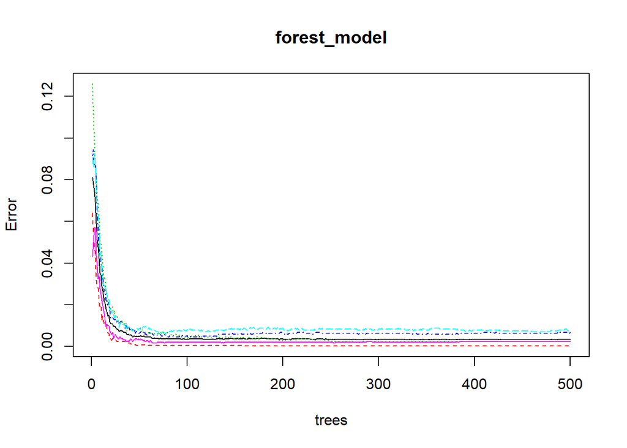

```r
plot(forest_model)
```

```r
#Testing
predict_forest <- predict(forest_model, newdata=Test_final, type="class")
conf_forest <- confusionMatrix(predict_forest, Test_final$classe)
conf_forest
```

```
## Confusion Matrix and Statistics
##
##           Reference
## Prediction    A    B    C    D    E
##          A 1674    1    0    0    0
##          B    0 1138    5    0    0
##          C    0    0 1021    8    0
##          D    0    0    1  957    2
##          E    0    0    0    0 1080
##
## Overall Statistics
##
##                Accuracy : 0.9971
##                  95% CI : (0.9954, 0.9983)
##     No Information Rate : 0.2844
##     P-Value [Acc > NIR] : < 2.2e-16
##
##                   Kappa : 0.9963
##  Mcnemar's Test P-Value : NA
##
## Statistics by Class:
##
##                      Class: A Class: B Class: C Class: D Class: E
## Sensitivity            1.0000   0.9991   0.9942   0.9917   0.9982
## Specificity            0.9998   0.9989   0.9984   0.9994   1.0000
## Pos Pred Value         0.9994   0.9956   0.9922   0.9969   1.0000
## Neg Pred Value         1.0000   0.9998   0.9988   0.9984   0.9996
## Prevalence             0.2844   0.1935   0.1745   0.1639   0.1838
## Detection Rate         0.2844   0.1933   0.1734   0.1626   0.1835
## Detection Prevalence   0.2845   0.1942   0.1748   0.1631   0.1835
## Balanced Accuracy      0.9999   0.9990   0.9963   0.9956   0.9991
```

### Selecting a Modle

Rondom Foreset is a good candidate

### Testing Data

```r
#Reading test data
real_test<-read.csv("https://d396qusza40orc.cloudfront.net/predmachlearn/pml-testing.csv")
#Predict test data
predict_test<- predict(forest_model,newdata=real_test,type="class")
head(predict_test)
```

```
## 1 2 3 4 5 6
## B A B A A E
## Levels: A B C D E
```